# A09

Olivia Martin

2022-11-07

**Instructions.** Change the author name on line 3 to be your name. Insert all requested answers. Upload in Moodle this file and a knitted file (html, doc, or pdf).

Answer the following reading questions (Read) and problems (Prob) from *Statistical Modeling: End-of-Chapter Exercises* by Daniel Kaplan. You should not need to refer to Kaplan, although his multiple choice answers to some problems may provide greater confidence when coming up with your answers.

**Read 10.01 (4 points).** What is a covariate? Why use a special word for it when it is just a variable?

A covariate is a variable that you notably don’t want to deal with. It denotes that your model’s effectiveness specifically depends on that variable being held constant, or that you’re trying to model a situation in which it’s constant.

**Read 10.02 (4 points).** What is the difference between a partial change and a total change?

A partial change describes the change made by changing the value of a particular explanatory variable while holding others constant, despite potential interaction. For example, if you have a model `a ~ b + c + b:c` and change `b` but not `b:c`, the change in the model value of `a` would be a partial change. If you don’t hold any variables constant, you’ll get a total change. Models with covariates often depict partial changes.

**Read 10.03 (4 points).** In the experimental method, how are covariates dealt with?

If you’re doing an experiment, you deal with covariates by actually holding the variable constant. For example, when studying the effect of humidity on the decomposition of a body, you can place the body in a climate-controlled room and hold temperature constant in order to avoid the confounding variables of temperature, interaction between temperature and humidity, and wildlife interference.

**Read 10.04 (4 points).** What is the modeling approach to dealing with covariates?

When you make your model, you assign the covariate some value and observe the partial relationship between the other variables.

**Read 10.05 (4 points).** What is Simpson’s paradox?

Simpson’s paradox occurs when the total relationship between variables looks one way, but controls for confounding variables reveal a distinctly different or opposite relationship. I didn’t know what this was at the time, but it’s the reason I got my first tattoo.

**Prob 10.01 (9 points)**. Consider the `Kidsfeet` data set.

1. First, you’re going to look at a total change. Build a model of foot width as a function of foot length: `width ∼ length`. Fit this model to the kids’ feet data. According to this model, how much does the typical width change when the foot length is increased from 22 to 27 cm?

   ```r
   coef(lm(width ~ length, data = KidsFeet))
   ```

   ```
   ## (Intercept)      length
   ##   2.8622761   0.2479478
   ```

   ```r
   5*0.2479478
   ```

   ```
   ## [1] 1.239739
   ```

   According to this model, a 5 cm increase in foot length corresponds to an increase of approximately 1.24 cm in width.

This is a total change, because it doesn’t hold any other variable constant, e.g. sex. That might sound silly, since obviously a kid’s sex doesn’t change as his or her foot grows. But the model doesn’t know that. It happens that most of the kids with foot lengths near 22 cm are girls, and most of the kids with foot lengths near 27 cm are boys. So when you compare feet with lengths of 22 and 27, you are effectively changing the sex at the same time as you change the foot length.

2. To look at a partial change, holding sex constant, you need to include sex in the model. A simple way to do this is `width ∼ length + sex`. Using this model fitted to the kids’ feet data, how much does a typical foot width change if the foot length is increased from 22 to 27 cm?

   ```r
   coef(lm(width ~ length + sex, data = KidsFeet))
   ```

   ```
   ## (Intercept)      length        sexG
   ##   3.6411683   0.2210250  -0.2325175
   ```

   ```r
   5*0.2210250
   ```

   ```
   ## [1] 1.105125
   ```

   According to this model, a 5 cm increase in foot length corresponds to an increase of approximately 1.11 cm in width.
3. You can also build more detailed models, for example a model that includes an interaction term: `width ∼ length * sex`. Using this model fitted to the kids’ feet data, how much will a typical girl’s foot width change if the foot length is increased from 22 to 27 cm?

   ```r
   coef(lm(width ~ length * sex, data = KidsFeet))
   ```

   ```
   ## (Intercept)      length        sexG length:sexG
   ##  3.85208056  0.21262376 -0.62387903  0.01582067
   ```

   ```r
   5*(0.21262376+0.01582067)
   ```

   ```
   ## [1] 1.142222
   ```

   According to this model, a 5 cm increase in a girl’s foot length corresponds to an increase of approximately 1.14 cm in width.

**Prob 10.02 (30 points).** In each of the following, a situation is described and a question is asked that is to be answered by modeling. Several variables are listed. Imagine an appropriate model and identify each variable as either the response variable, an explanatory variable, a covariate, or a variable to be ignored.

Police Foot vs. Car Patrols

Some people have claimed that police foot patrols are more effective at reducing the crime rate than patrols done in automobiles. Data from several different cities is available; each city has its own fraction of patrols done by foot, its own crime rate, etc. The mayor of your town has asked for your advice on whether it would be worthwhile to shift to more foot patrols in order to reduce crime. She asks, “Is there evidence that a larger fraction of foot patrols reduces the crime rate?”

Variables (answer response, explanatory, covariate, or ignore):

1. Crime rate (e.g., robberies per 100000 population) variable.

   response
2. Fraction of foot patrols

   explanatory
3. Number of policemen per 1000 population

   covariates
4. Demographics (e.g., poverty rate)

   covariates

Answer comments: The question focuses on how the fraction of foot patrols might influence crime rate, so crime rate is the response variable and fraction of foot patrols is an explanatory variable. But, the crime rate might also depend on the overall level of policing (as indicated by the number of policemen), or on the social conditions that are associated with crime (e.g., demographics). Since the mayor has no power to change the demographics of your town, and probably little power to change the overall level number of policemen, in modeling the data from the different cities, you would want to hold constant number of policemen and the demographics. You can do this by treating number of policemen and demographics as covariates and including them in your model.

Alcohol and Road Safety

Fifteen years ago, your state legislature raised the legal drinking age from 18 to 21 years. An important motivation was to reduce the number of car accident deaths due to drunk or impaired drivers. Now, some people are arguing that the 21-year age limit encourages binge drinking among 18 to 20 year olds and that such binge drinking actually increases car accident deaths. But the evidence is that the number of car accident deaths has gone down since the 21-year age restriction was introduced. You are asked to examine the issue:

Does the reduction in the number of car-accident deaths per year point to the effectiveness of the 21-year drinking age?

Variables (answer response, explanatory, covariate, or ignore):

1. Drinking age limit. Levels: 18 or 21.

   Explanatory
2. Number of car-accident deaths per year.

   Response
3. Prevalence of seat-belt use.

   Covariate
4. Fraction of cars with air bags.

   Covariate
5. Number of car accidents (with or without death).

   Ignore

With the variables listed, it’s important to note that airbags and seat belts significantly decrease the risk of death in a car accident, and depending on the 15-year period, their prevalence may have changed quite significantly. In this case I would choose to ignore the total number of car accidents because we’re looking specifically at car accident deaths. That data might be helpful in determining if the increase in drinking age effects the severity of a crash (i.e., same overall number of crashes but a lot fewer are fatal perhaps because a lot fewer involve drunk teens who already can’t drive that well).

However, these variables are not sufficient to make an argument either way. This list is missing a couple of extremely important variables that would be included in police data. It’s not possible to tell if the change in legal drinking age is effective in reducing deaths due to drunk driving unless you know the age and BAC of the people involved in said accidents. You can try to eliminate other variables as best you can, but nobody can think of or control every possible variable. Seat belts and airbags could easily account for the overall downward trend in crash fatalities, but because the 18-20 population accounts for so few of the drivers, a sharp increase in crash fatalities in that age range could be obscured. It’s also possible that better driver’s ed decreases crash fatalities among young people, so maybe crash fatalities became rarer among sober teen drivers but binge drinking caused an increase in overall crash fatalities among teen drivers.

Rating Surgeons

Your state government wants to guide citizens in choosing physicians. As part of this effort, they are going to rank all the surgeons in your state. You have been asked to build the rating system and you have a set of variables available for your use. These variables have been measured for each of the 342,861 people who underwent surgery in your state last year: one person being treated by one doctor. How should you construct a rating system that will help citizens to choose the most effective surgeon for their own treatment?

Variables (answer response, explanatory, covariate, or ignore):

1. Outcome score. A high score means that the operation did what it was supposed to. A low score reflects failure, e.g. death. Death is a very bad outcome, post-operative infection a somewhat bad outcome.)

   Response
2. Surgeon. One level for each of the operating surgeons.

   Explanatory
3. Experience of the surgeon.

   Ignore (kind of— see below)
4. Difficulty of the case.

   Covariate, but this would have to account for a lot of things, such as complexity of the surgery, equipment available to the surgeon, and comorbidities in the patient, among other things.

This is difficult, partly because I really don’t believe it’s helpful to reduce the complexities of medical effectiveness to scores like this. For example, it’s important to note that some types of surgeons naturally have higher rates of complication or death because of their specialties. Trauma surgeons are going to see more deaths than orthopedic surgeons because their cases are by definition much more complicated and risky.

Making the call on experience was really tough, and I thought about it for a long time. Typically the reason you would prefer a more experienced surgeon is because you assume their experience has made them better, which would be reflected in their outcome scores. However, advances in medicine mean that many surgeries are naturally a lot safer now, so a surgeon who has been practicing for 25 years might have a higher rate of infection than a surgeon who has been practicing for five years because of the advancements made in the intervening 20 years. I think rather than controlling for experience of the surgeon, I would control for the type of surgery and the year in which the surgery was performed (both of which should be easily available variables), because that allows you to more accurately control for the aspect of experience that would confound the outcome score. This could also be included in the “difficulty of the case” variable.

School testing

Last year, your school district hired a new superintendent to “shake things up.” He did so, introducing several controversial new policies. At the end of the year, test scores were higher than last year. A representative of the teachers’ union has asked you to examine the score data and answer this question: Is there reason to think that the higher scores were the result of the superintendent’s new policies?

Variables (answer response, explanatory, covariate, or ignore):

1. Superintendent (levels: New or Former superintendent)

   Explanatory
2. Exam difficulty

   Covariate
3. Test scores

   Response

I was going to write a long involved essay about why this still has a lot of confounding variables in it, but we talked about most of it, so here’s the rest: as a researcher, I would not feel professionally or ethically comfortable trying to make this call with only these variables. I would need to know what the new policies actually are, if they have been determined to be effective in other school districts, and if possible I would want to model the effectiveness of each independently of the others. I would need to know if there were other new policies, perhaps at the state or national level, that could have improved test scores. I would also like to know if support for students with learning disabilities had increased, because that would indicate more of a correction of test scores compared with past years than an improvement among the general student body.

Gravity

In a bizarre twist of time, you find yourself as Galileo’s research assistant in Pisa in 1605. Galileo is studying gravity: Does gravity accelerate all materials in the same way, whether they be made of metal, wood, stone, etc.? Galileo hired you as his assistant because you have brought with you, from the 21st century, a stop-watch with which to measure time intervals, a computer, and your skill in statistical modeling. All of these seem miraculous to him. He drops objects off the top of the Leaning Tower of Pisa and you measure the following:

Variables (answer response, explanatory, covariate, or ignore):

1. The size of the object (measured by its diameter).

   Covariate
2. Time of fall of the object.

   Response
3. The material from which the object is made (brass, lead, wood, stone).

   Explanatory

Ostensibly you would want to control for the size of the material you’re dropping, because with my 21st century knowledge I know about things like air resistance. Otherwise, this one is actually fairly straightforward.

[Thanks to James Heyman.]

**Prob 10.04 (9 points).** Economists measure the inflation rate as a percent change in price per year. Unemployment is measured as the fraction (percentage) of those who want to work who are seeking jobs.

According to economists, in the short run – say, from one year to another – there is a relationship between inflation and unemployment: all other things being equal, as unemployment goes up, inflation should go down. (The relationship is called the *Phillips curve*, but you don’t need to know that or anything technical about economics to do this question.)

1. If this is true, in the model `Inflation ~ Unemployment`, what should be the sign of the coefficient on Unemployment? Choose among positive, zero, and negative.

   Negative

But despite the short term relationship, economists claim that In the long run – over decades – unemployment and inflation should be unrelated.

2. If this is true, in the model `Inflation ~ Unemployment`, what should be the sign of the coefficient on Unemployment? Choose among positive, zero, and negative.

   Zero

The point of this exercise is to figure out how to arrange a model so that you can study the short-term behavior of the relationship, or so that you can study the long term relationship.

For your reference, here is a graph showing a scatter plot of inflation and unemployment rates over about 30 years in the US. Each point shows the inflation and unemployment rates during one quarter of a year. The plotting symbol indicates which of three decade-long periods the point falls into.

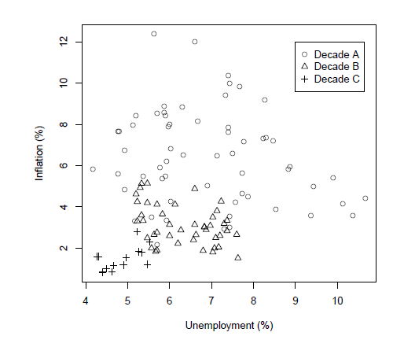

The relationship between inflation and unemployment seems to be different from one decade to another – that’s the short term.

3. Which decade seems to violate the economists’ Phillips Curve short-term relationship? Choose among A, B, C, none, or all.

   Decade C

Using the modeling language, express these different possible relationships between the variables `Inflation`, `Unemployment`, and `Decade`, where the variable `Decade` is a categorical variable with the three different levels shown in the legend for the graph. For the next four questions, choose your answer from among the following:

```
A. `Inflation ~ Decade`
B. `Inflation ~ Unemployment`
C. `Inflation ~ Unemployment + Decade`
D. `Inflation ~ Unemployment * Decade`
```

4. Inflation depends on Unemployment in a way that doesn’t change over time. B
5. Inflation changes with the decade, but doesn’t depend on Unemployment. A
6. Inflation depends on Unemployment in the same way every decade, but each decade introduces a new background inflation rate independent of Unemployment. C
7. Inflation depends on Unemployment in a way that differs from decade to decade. D

```
A. Hold Decade constant. (Partial change)
B. Let Decade vary as it will. (Total change)
```

**Prob 10.11 (4 points).** A study on drug D indicates that patients who were given the drug were less likely to recover from their condition C. Here is a table showing the overall results:

| Drug | # recovered | # died | Recovery Rate |
| --- | --- | --- | --- |
| Given | 1600 | 2400 | 40% |
| Not given | 2000 | 2000 | 50% |

Strangely, when investigators looked at the situation separately for males and females, they found that the drug improves recovery for each group:

Females

| Drug | # recovered | # died | Recovery Rate |
| --- | --- | --- | --- |
| Given | 900 | 2100 | 30% |
| Not given | 200 | 800 | 20% |

Males

| Drug | # recovered | # died | Recovery Rate |
| --- | --- | --- | --- |
| Given | 700 | 300 | 70% |
| Not given | 1800 | 1200 | 60% |

Which is right? Does the drug improve recovery or hinder recovery? What advice would you give to a physician about whether or not to prescribe the drug to her patients? Give enough of an explanation that the physician can judge whether your advice is reasonable.

I have a lot of things to say about sex differences in medicine. The most relevant one in this case is that having women adequately represented in drug trials AND having sex-disaggregated data would be a literal dream come true.

That aside, the gist is this: female patients seem to have a far lower recovery rate for condition C than males overall, and this study seems to have been somewhat poorly designed because female patients were given the drug 75% of the time, whereas male patients were only given the drug 25% of the time. Both groups should be 50-50 in random assignment in order to avoid things like this. But by controlling for that in post, we can see that both males and females saw a 10% increase in recovery rate when the drug was given. I would need to look for relationships between recovery rate and other variables (age, severity, etc.) before making a complete conclusion, but this data suggests that the drug is effective.

Based on an example from Judea Pearl (2000) *Causality: Models, Reasoning, and Inference*, Cambridge Univ. Press, p. 175.